# Lab 5

```python
import pandas as pd
from sklearn.pipeline import Pipeline
from sklearn.linear_model import LinearRegression
from sklearn.metrics import r2_score
from sklearn.preprocessing import OneHotEncoder
from sklearn.model_selection import train_test_split
from sklearn.compose import ColumnTransformer
from sklearn.preprocessing import PolynomialFeatures
from sklearn.metrics import r2_score
from sklearn.metrics import mean_squared_error
from plotnine import ggplot, aes, geom_point, geom_bar, labs, geom_smooth, geom_boxplot, geom_hline, theme_minimal, ggtitle
```

```python
df = pd.read_csv('https://www.dropbox.com/s/bocjjyo1ehr5auz/insurance_costs_1.csv?dl=1')
```

```python
df.head()
```

|  | age | sex | bmi | smoker | region | charges |
| --- | --- | --- | --- | --- | --- | --- |
| 0 | 19 | female | 27.900 | yes | southwest | 16884.92400 |
| 1 | 33 | male | 22.705 | no | northwest | 21984.47061 |
| 2 | 32 | male | 28.880 | no | northwest | 3866.85520 |
| 3 | 31 | female | 25.740 | no | southeast | 3756.62160 |
| 4 | 60 | female | 25.840 | no | northwest | 28923.13692 |

# Part 1

```python
df.describe()
```

|  | age | bmi | charges |
| --- | --- | --- | --- |
| count | 431.000000 | 431.000000 | 431.000000 |
| mean | 37.960557 | 30.768898 | 12297.098118 |
| std | 16.363909 | 6.111362 | 11876.527128 |
| min | 18.000000 | 15.960000 | 1131.506600 |
| 25% | 22.000000 | 26.357500 | 2710.444575 |
| 50% | 34.000000 | 30.590000 | 9866.304850 |
| 75% | 55.000000 | 35.272500 | 14510.872600 |
| max | 64.000000 | 49.060000 | 55135.402090 |

```python
df['region'].value_counts()
```

```
southeast    125
northeast    108
southwest    103
northwest     95
Name: region, dtype: int64
```

```python
df['sex'].value_counts()
```

```
female    225
male      206
Name: sex, dtype: int64
```

```python
df['smoker'].value_counts()
```

```
no     344
yes     87
Name: smoker, dtype: int64
```

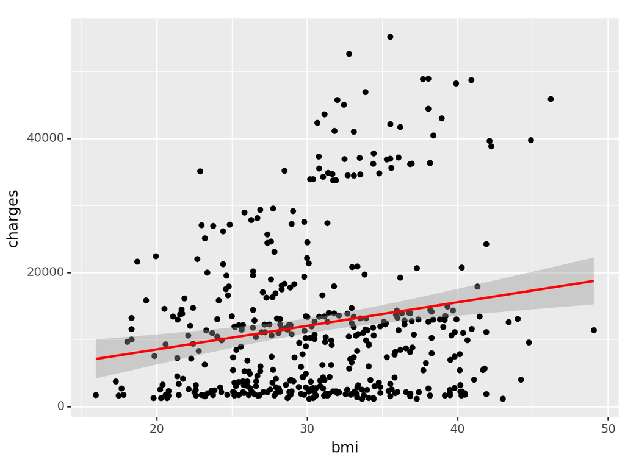

```
<Figure Size: (640 x 480)>
```

```python
(ggplot(df, aes(x='bmi',y='charges'))+geom_point()+geom_smooth(method="lm", color="red"))
```

This graph implies a positively correlated relationship between bmi and insurance charges. In terms of ethical considerations, I wouldn’t consider this a completely ethical way to determine charges, as bmi has been proven to be an often incorrect way to determine someone’s health.

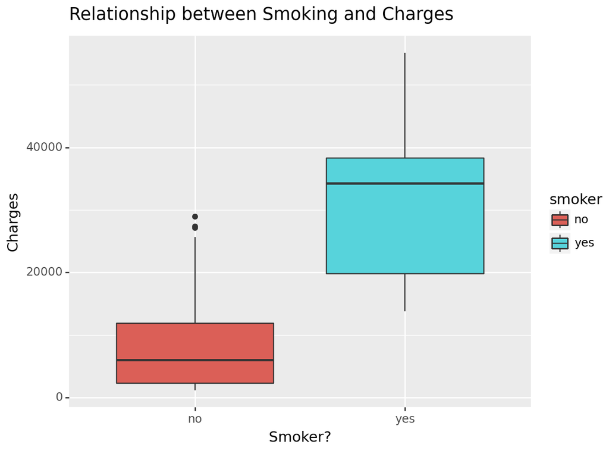

```
<Figure Size: (640 x 480)>
```

```python
(ggplot(df, aes(x='smoker', y='charges', fill='smoker'))
 + geom_boxplot()
 + labs(title="Relationship between Smoking and Charges",
        x="Smoker?",
        y="Charges"))
```

This boxplot shows that there is a clear relationship between being a smoker and having higher insurance charges. The 3rd quartile for non-smokers is significantly below the 1st quartile of smokers.

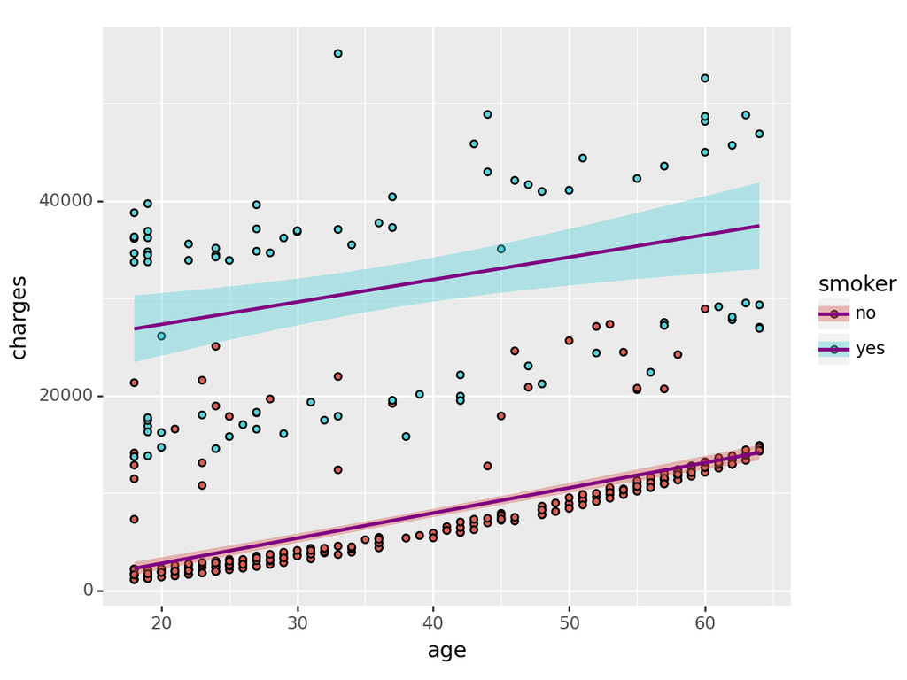

```
<Figure Size: (640 x 480)>
```

```python
(ggplot(df, aes(x='age',y='charges', fill='smoker'))+geom_point()+geom_smooth(method="lm", color="purple"))
```

As age increases, the insurance charges increase. This makes sense, because as people age they often have more health ailments. I decided to still break down by smoker because the difference between smokers and non smokers is so significant that my line of best fit was unrealistic for most of the datapoints.

# Part 2

```python
X = pd.get_dummies(df[['sex','age','bmi','smoker','region']], drop_first = True)
y = df['charges']
```

### Problem 1

```python
X1 = X[['age']]
X_train, X_test, y_train, y_test = train_test_split(X1,y)
lr = LinearRegression()

my_pipeline1 = Pipeline(
    [('ols',lr)]
)
fitted_pipeline1=my_pipeline1.fit(X_train, y_train)
y_preds1=fitted_pipeline1.predict(X_test)

r1 = r2_score(y_test, y_preds1)
mse1 = mean_squared_error(y_test, y_preds1)

coefficients = fitted_pipeline1.named_steps['ols'].coef_

print("Coefficient Estimates:")
print("Intercept:", fitted_pipeline1.named_steps['ols'].intercept_)
print("Age:", coefficients[0])
print("R squared:")
print(r1)
print("MSE:")
print(mse1)
```

```
Coefficient Estimates:
Intercept: 3956.690263404169
Age: 233.76574981435223
R squared:
0.07946942994189099
MSE:
76794719.75205901
```

The R squared for this model is very low, which makes sense looking at my graph between age and charges - the points are very widely distributed and therefore a simple linear model would not perform well. The coefficients imply that the average charges tarts at $3956, and for every added year you would expect a $233 increase in charges.

### Problem 2

```python
enc = OneHotEncoder()
lr = LinearRegression()

X1 = X[['sex_male','age']]

my_new_pipeline = Pipeline(
    [('ols',lr)]
)

X_train, X_test, y_train, y_test = train_test_split(X1,y, test_size=0.25)

fitted_pipeline2=my_new_pipeline.fit(X_train, y_train)
y_preds=fitted_pipeline2.predict(X_test)
r2=r2_score(y_test, y_preds)
mse2 = mean_squared_error(y_test, y_preds)

coefficients = fitted_pipeline2.named_steps['ols'].coef_

print("Coefficients: ")
print(coefficients)
print("R squared: ")
print(r2)
print("MSE:")
print(mse2)
```

```
Coefficients:
[722.35065386 233.32452247]
R squared:
0.0847946826988939
MSE:
134067812.92644128
```

The first coefficient is for sex_male and the last one is for age. The effect of the variables varies greatly every time I run the model and the R squared is always very low. The last time I ran it, the coefficient for sex_male was 722.35 which means that the charges for men are $722 higher. For age it was 233, which means that every year someone ages their charges increase $233, on estimate.

### Problem 3

```python
my_new_pipeline = Pipeline(
    [('ols',lr)]
)

X1 = X[['smoker_yes','age']]
y = df['charges']
X_train, X_test, y_train, y_test = train_test_split(X1,y, test_size=0.25)

fitted_pipeline3=my_new_pipeline.fit(X_train, y_train)
y_preds=fitted_pipeline3.predict(X_test)
r3=r2_score(y_test, y_preds)
mse3 = mean_squared_error(y_test, y_preds)

coefficients = fitted_pipeline3.named_steps['ols'].coef_

print("Coefficients: ")
print(coefficients)
print("R squared: ")
print(r3)
print("MSE:")
print(mse3)
```

```
Coefficients:
[24342.10912157   257.9228358 ]
R squared:
0.6977127869390578
MSE:
37480570.74310871
```

The first coefficient is for smoker_yes. The value is very high, because it very greatly affects the charges, as shown in the above graphs. If someone is a smoker, it is estimated that their charges would increase $24342. Age is less of a factor, but still significant - as someone ages on year, their charges are estimated to increase $257. The R squared is relatively high at 0.6978.

### Problem 4

When I last ran the models, the MSE for model 2 was 134067812 and for model 3 was 37480570, which is significantly lower. The R squared for model 3 is also always significantly higher than model 2. Therefore, model 3 fits the data better.

# Part 3

### Problem 1

```python
X1 = X[['age', 'bmi']]
y = df['charges']
X_train, X_test, y_train, y_test = train_test_split(X1,y)
lr = LinearRegression()

my_pipeline1 = Pipeline(
    [('ols',lr)]
)
fitted_pipeline1=my_pipeline1.fit(X_train, y_train)
y_preds1=fitted_pipeline1.predict(X_test)

r1 = r2_score(y_test, y_preds1)
mse1 = mean_squared_error(y_test, y_preds)

coefficients = fitted_pipeline1.named_steps['ols'].coef_

print("Coefficient Estimates:")
print(coefficients)
print("R squared:")
print(r1)
print("MSE:")
print(mse1)
```

```
Coefficient Estimates:
[226.35989759 318.60943238]
R squared:
0.08281376703295307
MSE:
139432160.52744916
```

The R squared and MSE for the two models are at similar degrees, but they change quite a bit every time I run the model. They both have a relatively low R squared, usually between 0.5 and 0.15 but sometimes lower, and both have a 9 digit MSE around 100000000. Overall, both are not performing well.

### Problem 2

```python
pol2 = PolynomialFeatures((1,2))

ct2 = ColumnTransformer(
    [('poly2',pol2,['age'])]
)

my_pipeline2 = Pipeline(
    [('poly_everything',ct2),('ols',lr)]
)

X1 = df[['age']]
y = df['charges']
X_train, X_test, y_train, y_test = train_test_split(X1,y)

fitted_pipeline=my_pipeline2.fit(X_train, y_train)
y_preds=fitted_pipeline.predict(X_test)

r1 = r2_score(y_test, y_preds)
mse1 = mean_squared_error(y_test, y_preds)

coefficients = fitted_pipeline.named_steps['ols'].coef_

print("Coefficient Estimates:")
print(coefficients)
print("R squared:")
print(r1)
print("MSE:")
print(mse1)
```

```
Coefficient Estimates:
[  0.         158.19665897   0.69955479]
R squared:
0.1178470267449353
MSE:
115702880.6076861
```

The R squared and MSE are again very similar, and not very good.

### Problem 3

```python
pol4 = PolynomialFeatures((1,4))

ct2 = ColumnTransformer(
    [('poly4',pol4,['age'])]
)

my_pipeline2 = Pipeline(
    [('poly_everything',ct2),('ols',lr)]
)

X1 = df[['age']]
y = df['charges']
X_train, X_test, y_train, y_test = train_test_split(X1,y)

fitted_pipeline=my_pipeline2.fit(X_train, y_train)
y_preds=fitted_pipeline.predict(X_test)

r1 = r2_score(y_test, y_preds)
mse1 = mean_squared_error(y_test, y_preds)

coefficients = fitted_pipeline.named_steps['ols'].coef_

print("Coefficient Estimates:")
print(coefficients)
print("R squared:")
print(r1)
print("MSE:")
print(mse1)
```

```
Coefficient Estimates:
[ 0.00000000e+00 -7.06463663e+03  3.04667452e+02 -5.34990599e+00
  3.35407905e-02]
R squared:
0.0827978479174295
MSE:
138555236.6611636
```

The R squared for this model is generally a bit lower than the original model ,usually being under 0.1, and the MSE is often higher.

### Problem 4

```python
pol12 = PolynomialFeatures((1,12))

ct2 = ColumnTransformer(
    [('poly12',pol12,['age'])]
)

my_pipeline2 = Pipeline(
    [('poly_everything',ct2),('ols',lr)]
)

X1 = df[['age']]
y = df['charges']
X_train, X_test, y_train, y_test = train_test_split(X1,y)

fitted_pipeline=my_pipeline2.fit(X_train, y_train)
y_preds=fitted_pipeline.predict(X_test)

r1 = r2_score(y_test, y_preds)
mse1 = mean_squared_error(y_test, y_preds)

coefficients = fitted_pipeline.named_steps['ols'].coef_

print("Coefficient Estimates:")
print(coefficients)
print("R squared:")
print(r1)
print("MSE:")
print(mse1)
```

```
Coefficient Estimates:
[ 0.00000000e+00 -1.31986662e-05 -1.41640922e-08 -3.29477113e-07
 -5.43705575e-06 -6.46560185e-05 -4.29735179e-04  6.19984999e-05
 -3.49893634e-06  1.01317981e-07 -1.60376181e-09  1.32297994e-11
 -4.45854748e-14]
R squared:
0.04831770131551183
MSE:
131918255.25221185
```

The R squared for this model is also low, usually under 0.1, and the MSE is usually higher

### Problem 5

The best model, at this moment, is my quadratic model. However, it changes frequently. Also, this is definitely not the overall best model. It still has a very low R squared and very high MSE. There is room for improvement.

### Problem 6

```python
d = {'Age':X_test['age'],
     'Charges':y_test,
     'Prediction':y_preds}
res = pd.DataFrame(d)
res
```

|  | Age | Charges | Prediction |
| --- | --- | --- | --- |
| 387 | 48 | 8671.19125 | 14409.154638 |
| 126 | 26 | 3176.81590 | 9873.583437 |
| 2 | 32 | 3866.85520 | 12013.206288 |
| 116 | 18 | 1607.51010 | 7927.001479 |
| 128 | 46 | 7526.70645 | 13641.974745 |
| ... | ... | ... | ... |
| 32 | 55 | 10226.28420 | 15720.488206 |
| 350 | 63 | 13974.45555 | 21878.155924 |
| 278 | 58 | 11743.93410 | 15211.750982 |
| 345 | 27 | 3353.47030 | 10264.952378 |
| 367 | 33 | 3704.35450 | 12245.108635 |

108 rows × 3 columns

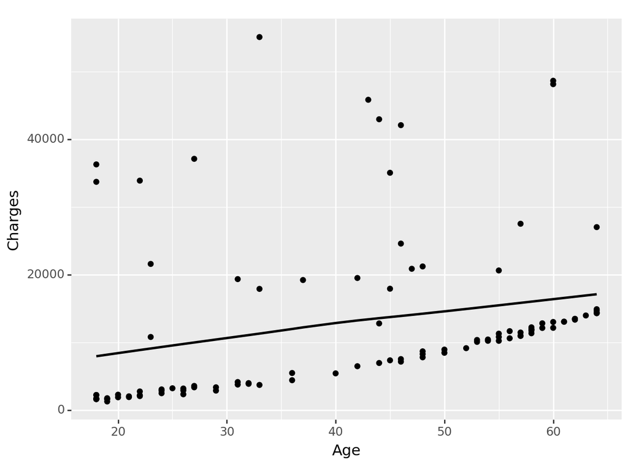

```
<Figure Size: (640 x 480)>
```

```python
p=(ggplot(res, aes(x='Age'))
+geom_point(aes(y='Charges'))
+geom_smooth(aes(y='Prediction')))
p
```

# Part 4

```python
newdf = pd.read_csv('https://www.dropbox.com/s/sky86agc4s8c6qe/insurance_costs_2.csv?dl=1')
```

```python
Xnew = pd.get_dummies(newdf[['sex','age','bmi','smoker','region']], drop_first = True)
ynew = newdf['charges']
```

```python
#Model 1
X1 = X[['age']]
y = df['charges']
X_train, X_test, y_train, y_test = train_test_split(X1,y)

Xnew1 = Xnew[['age']]

lr = LinearRegression()

my_pipeline1 = Pipeline(
    [('ols',lr)]
)

fitted_pipeline1=my_pipeline1.fit(X_train, y_train)
y_preds1=fitted_pipeline1.predict(Xnew1)

r1 = r2_score(ynew, y_preds1)
mse1 = mean_squared_error(ynew, y_preds1)

coefficients = fitted_pipeline1.named_steps['ols'].coef_

print("Coefficient Estimates:")
print(coefficients)
print("R squared:")
print(r1)
print("MSE:")
print(mse1)
```

```
Coefficient Estimates:
[260.50791944]
R squared:
0.1246553431176004
MSE:
135722043.4873233
```

```python
#Model 2
X1 = X[['age','bmi']]
y = df['charges']
X_train, X_test, y_train, y_test = train_test_split(X1,y)

Xnew1 = Xnew[['age','bmi']]


lr = LinearRegression()

my_pipeline1 = Pipeline(
    [('ols',lr)]
)

fitted_pipeline1=my_pipeline1.fit(X_train, y_train)
y_preds1=fitted_pipeline1.predict(Xnew1)

r1 = r2_score(ynew, y_preds1)
mse1 = mean_squared_error(ynew, y_preds1)

coefficients = fitted_pipeline1.named_steps['ols'].coef_

print("Coefficient Estimates:")
print(coefficients)
print("R squared:")
print(r1)
print("MSE:")
print(mse1)
```

```
Coefficient Estimates:
[244.97675922 325.1186168 ]
R squared:
0.14864333984324618
MSE:
132002708.58400962
```

```python
# Model 3
X1 = X[['age','bmi','smoker_yes']]
y = df['charges']
X_train, X_test, y_train, y_test = train_test_split(X1,y)

Xnew1 = Xnew[['age','bmi','smoker_yes']]
ynew = newdf['charges']

lr = LinearRegression()

my_new_pipeline = Pipeline(
    [('ols',lr)]
)

fitted_pipeline3=my_new_pipeline.fit(X_train, y_train)
y_preds=fitted_pipeline3.predict(Xnew1)


r3=r2_score(ynew, y_preds)
mse3 = mean_squared_error(ynew, y_preds)

coefficients = fitted_pipeline3.named_steps['ols'].coef_

print("Coefficients: ")
print(coefficients)
print("R squared: ")
print(r3)
print("MSE:")
print(mse3)
```

```
Coefficients:
[  236.29226133   287.63406291 24258.52479997]
R squared:
0.7711436375684324
MSE:
35484140.93816853
```

```python
# Model 4
X = pd.get_dummies(df[['smoker','bmi','age']], drop_first = True)
X['smoker-bmi'] = X['smoker_yes']*X['bmi']
X['smoker-age'] = X['smoker_yes']*X['age']
X = X.drop(['smoker_yes'], axis=1)
y = df['charges']

X_train, X_test, y_train, y_test = train_test_split(X,y)


Xnew = pd.get_dummies(newdf[['smoker','bmi','age']], drop_first = True)
Xnew['smoker-bmi'] = Xnew['smoker_yes']*Xnew['bmi']
Xnew['smoker-age'] = Xnew['smoker_yes']*Xnew['age']
Xnew = Xnew.drop(['smoker_yes'], axis=1)
ynew = newdf['charges']

my_new_pipeline = Pipeline(
    [('ols',lr)]
)

fitted_pipeline3=my_new_pipeline.fit(X_train, y_train)
y_preds=fitted_pipeline3.predict(Xnew)


r3=r2_score(ynew, y_preds)
mse3 = mean_squared_error(ynew, y_preds)

coefficients = fitted_pipeline3.named_steps['ols'].coef_

print("Coefficients: ")
print(coefficients)
print("R squared: ")
print(r3)
print("MSE:")
print(mse3)
```

```
Coefficients:
[  76.46491588  260.67417802  980.45242042 -136.75362757]
R squared:
0.8367495454323142
MSE:
25311955.833572254
```

```python
# Model 5
X = pd.get_dummies(df[['smoker','bmi','age']], drop_first = True)
X['smoker-bmi'] = X['smoker_yes']*X['bmi']
X['smoker-age'] = X['smoker_yes']*X['age']
y = df['charges']

X_train, X_test, y_train, y_test = train_test_split(X,y)


Xnew = pd.get_dummies(newdf[['smoker','bmi','age']], drop_first = True)
Xnew['smoker-bmi'] = Xnew['smoker_yes']*Xnew['bmi']
Xnew['smoker-age'] = Xnew['smoker_yes']*Xnew['age']
ynew = newdf['charges']

my_new_pipeline = Pipeline(
    [('ols',lr)]
)

fitted_pipeline3=my_new_pipeline.fit(X_train, y_train)
y_preds=fitted_pipeline3.predict(Xnew)


r3=r2_score(ynew, y_preds)
mse3 = mean_squared_error(ynew, y_preds)

coefficients = fitted_pipeline3.named_steps['ols'].coef_

print("Coefficients: ")
print(coefficients)
print("R squared: ")
print(r3)
print("MSE:")
print(mse3)
```

```
Coefficients:
[-1.59538705e+01  2.53070384e+02 -1.95820878e+04  1.45474259e+03
 -2.27436948e+01]
R squared:
0.8584036404210995
MSE:
21954492.006450962
```

Model 5 has the smallest MSE, at 21954492. Based on this, it is the best model to use.

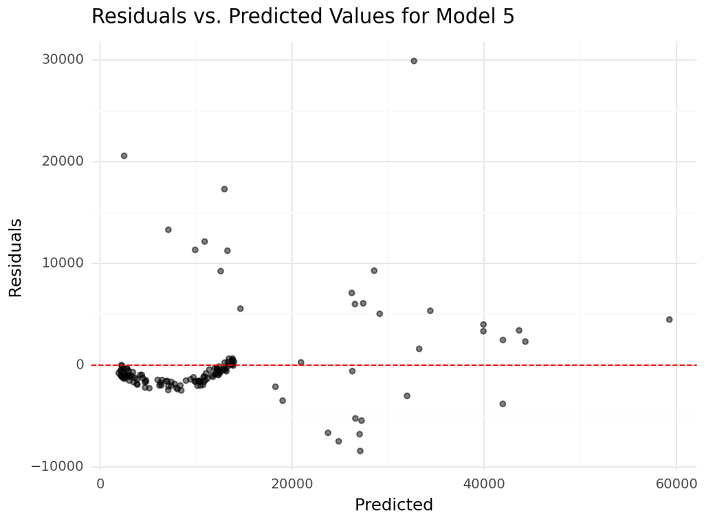

```python
residuals = ynew - y_preds
plot_df = pd.DataFrame({'Predicted': y_preds, 'Residuals': residuals})

(
    ggplot(plot_df, aes(x='Predicted', y='Residuals'))
    + geom_point(alpha=0.5)
    + geom_hline(yintercept=0, color="red", linetype="dashed")
    + theme_minimal()
    + ggtitle("Residuals vs. Predicted Values for Model 5")
).draw()
```

# Part 5

```python
# Combo model
X = pd.get_dummies(df[['smoker','bmi','age']], drop_first = True)
X['smoker-bmi'] = X['smoker_yes']*X['bmi']
y = df['charges']

X_train, X_test, y_train, y_test = train_test_split(X,y)


Xnew = pd.get_dummies(newdf[['smoker','bmi','age']], drop_first = True)
Xnew['smoker-bmi'] = Xnew['smoker_yes']*Xnew['bmi']
ynew = newdf['charges']

my_new_pipeline = Pipeline(
    [('ols',lr)]
)

fitted_pipeline3=my_new_pipeline.fit(X_train, y_train)
y_preds=fitted_pipeline3.predict(Xnew)


r3=r2_score(ynew, y_preds)
mse3 = mean_squared_error(ynew, y_preds)

coefficients = fitted_pipeline3.named_steps['ols'].coef_

print("Coefficients: ")
print(coefficients)
print("R squared: ")
print(r3)
print("MSE:")
print(mse3)
```

```
Coefficients:
[-3.07768856e+00  2.60446629e+02 -2.05621601e+04  1.46461075e+03]
R squared:
0.8611559259654745
MSE:
21527750.590477042
```

Using combinations of the different variables and their interactions as well as polynomical combinations of different variables, the highest R squared I can reach is around 0.86. Above is the code for that model. This model is very similar to Model 5 from Part Four, so the below graph is very similar.

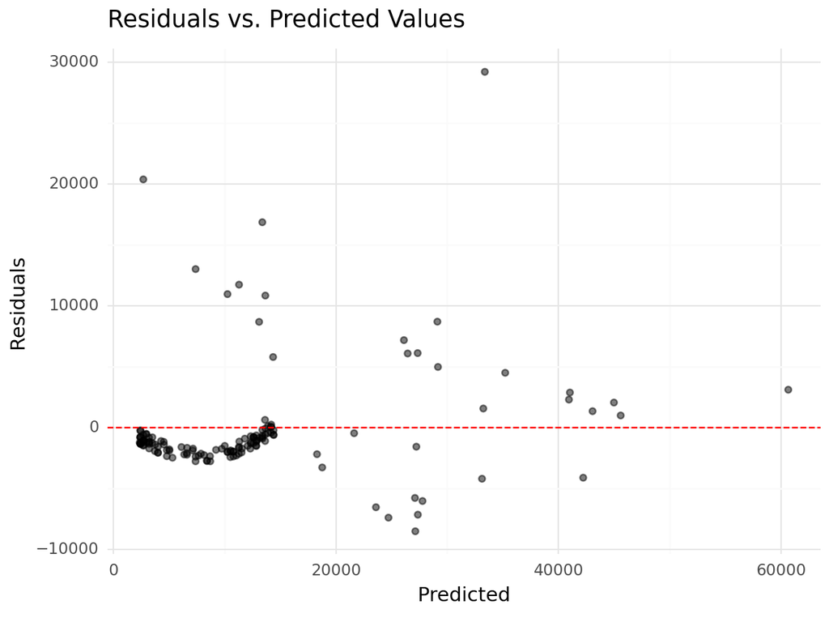

```python
residuals = ynew - y_preds
plot_df = pd.DataFrame({'Predicted': y_preds, 'Residuals': residuals})

(
    ggplot(plot_df, aes(x='Predicted', y='Residuals'))
    + geom_point(alpha=0.5)
    + geom_hline(yintercept=0, color="red", linetype="dashed")
    + theme_minimal()
    + ggtitle("Residuals vs. Predicted Values")
).draw()
```